# Ventas Apple

Carlos Rodríguez-Viña Martínez

16/11/2020

## Transformación de los datos

```r
fechas <- seq(as.Date("2008-04-01"), as.Date("2017-09-30"), by = "quarter")
apple <- mutate(IngresosApple, fecha = fechas)
str(apple)
```

```
## tibble [38 x 3] (S3: spec_tbl_df/tbl_df/tbl/data.frame)
##  $ Trimestre: chr [1:38] "Q2 2008" "Q3 2008" "Q4 2008" "Q1 2009" ...
##  $ Ingresos : num [1:38] 7980 7561 11520 11880 9084 ...
##  $ fecha    : Date[1:38], format: "2008-04-01" "2008-07-01" ...
##  - attr(*, "spec")=
##   .. cols(
##   ..   Trimestre = col_character(),
##   ..   Ingresos = col_double()
##   .. )
```

Lo pasamos a formato xts

```r
Sales = xts(apple$Ingresos, order.by = as.Date(apple$fecha, "%Y/%m/%d"), frequency = 4)
Sales = to.quarterly(Sales) #Generamso los datos en forma de trimestre
```

Lo pasamos a formato zoo.

```r
zVentas=as.zoo(Sales$Sales.Close)
zVentas
```

```
##         Sales.Close
## 2008 Q2        7980
## 2008 Q3        7561
## 2008 Q4       11520
## 2009 Q1       11880
## 2009 Q2        9084
## 2009 Q3        9734
## 2009 Q4       12207
## 2010 Q1       15683
## 2010 Q2       13499
## 2010 Q3       15700
## 2010 Q4       20343
## 2011 Q1       26741
## 2011 Q2       24667
## 2011 Q3       28571
```

[output cut: 24 more lines]

# Visualización de los Datos

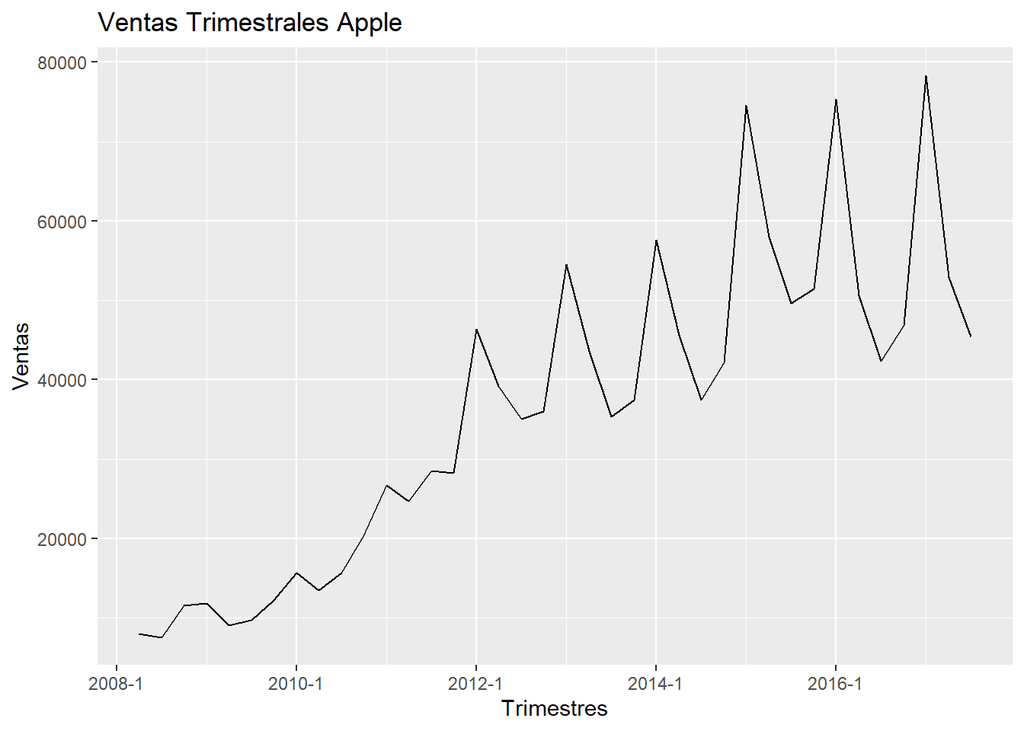

```r
autoplot(zVentas)+ylab("Ventas")+ggtitle("Ventas Trimestrales Apple")+xlab("Trimestres")
```

Observamos que tiene una tendencia positiva y parece que las ventas de un trimestre pueden estar explicadas por las ventas de otros trimestres. Aunque todavía es pronto para confirmarlo.

### Autocorrelacion

[figure not shown]

```r
zlVentas=log(zVentas)
df_newl <- data.frame(value = as.vector(zlVentas),
                     time = time(zlVentas))
ggplot(df_newl)+geom_point(aes(x=time,y=value))+geom_line(aes(x=time,y=value))+ylab("Ventas")+ggtitle("Ventas Trimestrales LOG CocaCola")+xlab("Trimestres")
```

La instalación de un modelo ARIMA requiere que la serie sea estacionaria . Se dice que una serie es estacionaria cuando su media, varianza y autocovarianza son invariantes en el tiempo.

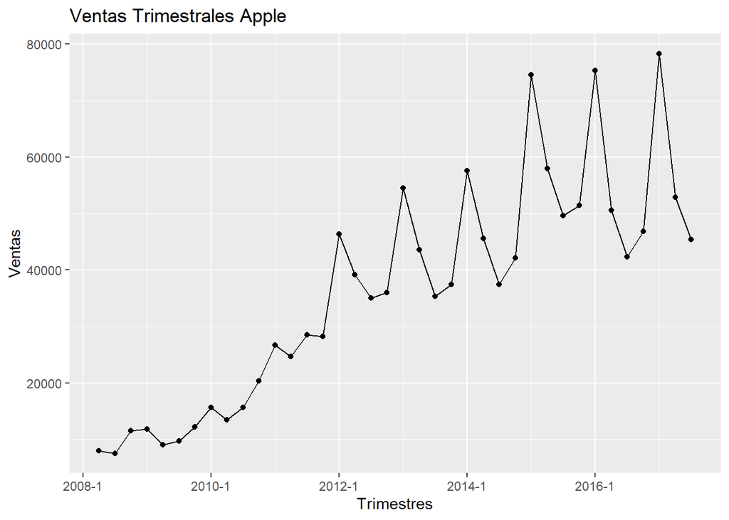

```r
df_new <- data.frame(value = as.vector(zVentas),
                     time = time(zVentas))
ggplot(df_new)+geom_point(aes(x=time,y=value))+geom_line(aes(x=time,y=value))+ylab("Ventas")+ggtitle("Ventas Trimestrales Apple")+xlab("Trimestres")
```

Esta suposición tiene un sentido intuitivo: dado que ARIMA usa retardos previos de series para modelar su comportamiento

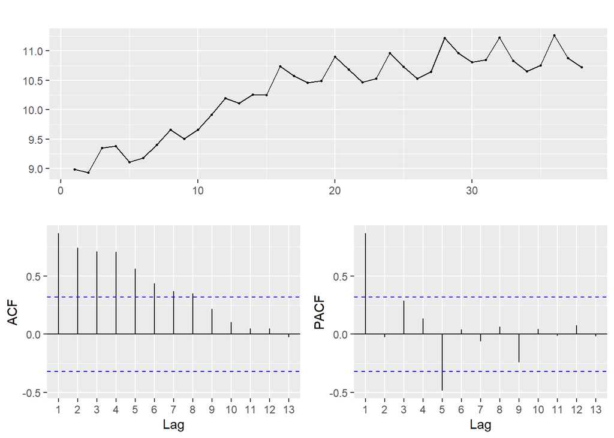

```r
ggtsdisplay(zlVentas)
```

Observando la primera gráfica podemos observar la autocorrelación que existe entre los datos, por la gráfica podemos observar que las observaciones estan correlacionadas indirectas hasta la octava observación anterior. La segunda gráfica me indica que existe una correlación entre la observación t y t-1 es decir la autocorrelación solo es con el trimestre anterior, lo extraño es que parece que tiene una correlaciín con t-5, investigando esto hemos descubierto que coincide con los lanzamiento de nuevos productos Apple.

Para realizar un modelo ARIMA, la serie temporal debe ser estacionaria. Para conseguir esta estacionariedad, la diferenciaremos.

```r
count_d1 =ggtsdisplay(diff(zlVentas))
```

[figure not shown]

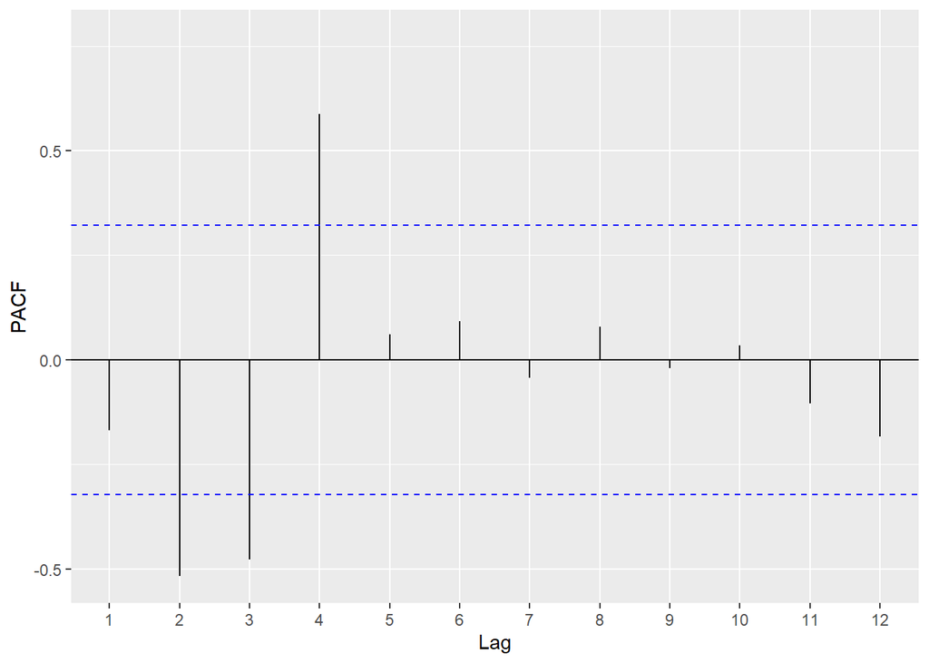

```r
count_d1
```

Podemos observar que efectivamente es estacional, por lo que podemos proceder a realizar el modelo ARIMA.